# Case Study 2025

1. Proszę wczytać zbiór danych `gospodarstwa-zajecia.xlsx` [2 min]
2. Proszę sprawdzić rozkłady zmiennych `los`, `dochg` i `wydg`. Co możemy o nich powiedzieć? [8 min]
   - Sprawdźcie: typ rozkładu, asymetrię, wartości odstające
   - Proszę obliczyć podstawowe statystyki (średnia, mediana, odch. std.)
   - Jaki % obserwacji jest brakujących?
3. Które zmienne i jak korelują z `los`, `dochg` i `wydg`? [15 min] Proszę przejrzeć zmienne dostępne w zbiorze danych i zastanowić się, które zmienne warto rozważyć jako pomocnicze.

   Sugerowane analizy:
   - Korelacje dla zmiennych numerycznych
   - Boxploty dla zmiennych kategorycznych
   - Dla wybranych zmiennych: porównanie rozkładów lub wstępna regresja

   Cel: zidentyfikować 3-5 najważniejszych zmiennych dla każdej zmiennej.
4. Jakie modele można rozważyć dla tych 3 zmiennych? [5 min] Dyskusja - proszę uwzględnić:
   - Typ zmiennej (ciągła, dyskretna, ograniczona?)
   - Rozkład (normalny, skośny, z wartościami skrajnymi?)
   - Możliwe modele (regresja liniowa, log-liniowa, inne?)
5. Proszę zaimputować brakujące dane w zmiennych `los`, `dochg` i `wydg` [40 min]

   Metody do zastosowania:
   1. Regresyjna deterministyczna
   2. Regresyjna stochastyczna
   3. k-NN z k=5 sąsiadów
   4. Predictive Mean Matching (PMM)

   Wskazówki:
   - Można użyć pakietu `mice` w R lub `sklearn` w Pythonie
   - Proszę używać tych samych zmiennych pomocniczych dla wszystkich metod (dla porównywalności)
   - Dla metod stochastycznych: ustalić seed dla powtarzalności
6. Dla wybranej metody proszę ocenić z wykorzystaniem wizualizacji danych jak wyglądają dane zaimputowane w porównaniu z tymi, które obserwujemy. Czy imputacja zachowuje rozkład? [5 min]
7. Dla każdej zmiennej i każdej metody imputacji proszę oszacować i zaraportować [10 min]:
   - Średnią z pełnego zbioru (po imputacji)
   - Średnią tylko z wartości oryginalnych (przed imputacją)
   - Średnią tylko z wartości zaimputowanych

   Proszę przedstawić wyniki w formie tabeli.
8. Porównanie i wnioski [5 min]:
   - Która metoda wydaje się najbardziej odpowiednia dla każdej zmiennej i dlaczego?
   - Czy któraś metoda systematycznie zawyża/zaniża wartości?
   - Jakie są implikacje dla dalszych analiz?

**R**

Kod na wczytanie pakietu do wczytania danych

```r
library(readxl)
library(simputation)
library(VIM)
library(data.table)
library(ggplot2)
library(patchwork)
```

```r
gosp <- read_excel("../data/gospodarstwa-zajecia.xlsx") |> setDT()
head(gosp)
```

```
     klm    woj   trb   zut   d21   d32  d345  d347  d348   d36   d38   d61
   <num> <char> <num> <num> <num> <num> <num> <num> <num> <num> <num> <num>
1:     1     02    11     5     2     1     1     2     1    69     2     3
2:     1     02     6     1     2     1     2     2     1    74     3     4
3:     1     02     3     1     1     3     1     2     1    83     3     4
4:     1     02    12     5     2     1     3     3     2    44     2     4
5:     1     02     1     5     1     3     1     2     1   110     5     4
6:     1     02    12     1     1     1     2     3     1    36     1     3
     d63   los dochg  wydg
   <num> <num> <num> <num>
1:     3    NA    NA    NA
2:     2    NA    NA    NA
3:     1    NA    NA    NA
4:     1    NA    NA    NA
5:     2    NA    NA    NA
6:     3    NA    NA    NA
```

Kod na wizualizacje i ocenę danych

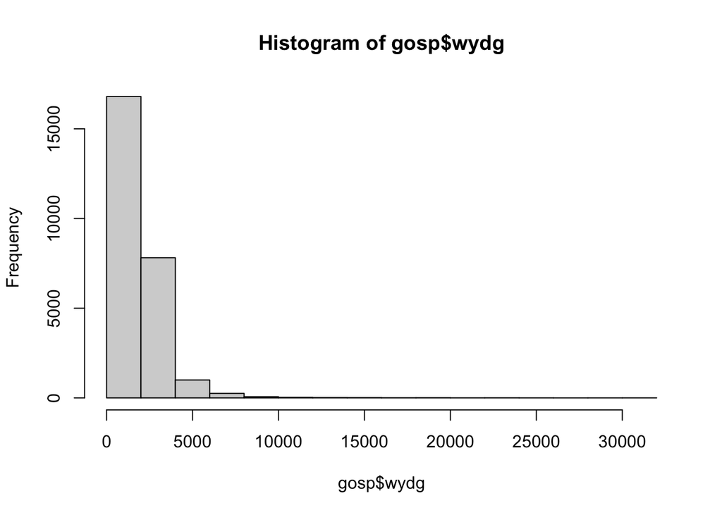

```r
hist(gosp$wydg)
```

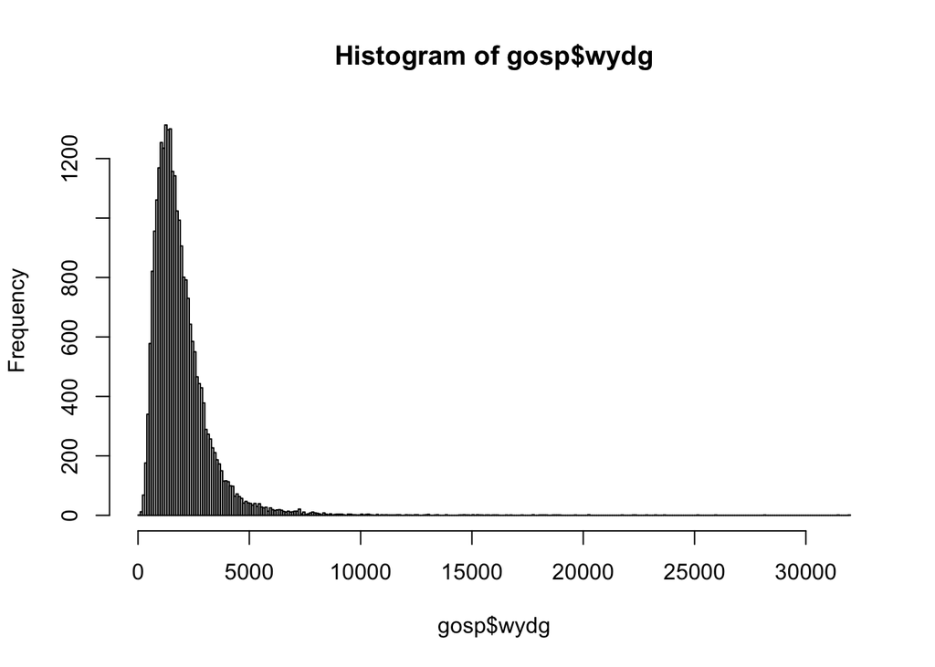

```r
hist(gosp$wydg, breaks = "fd")
```

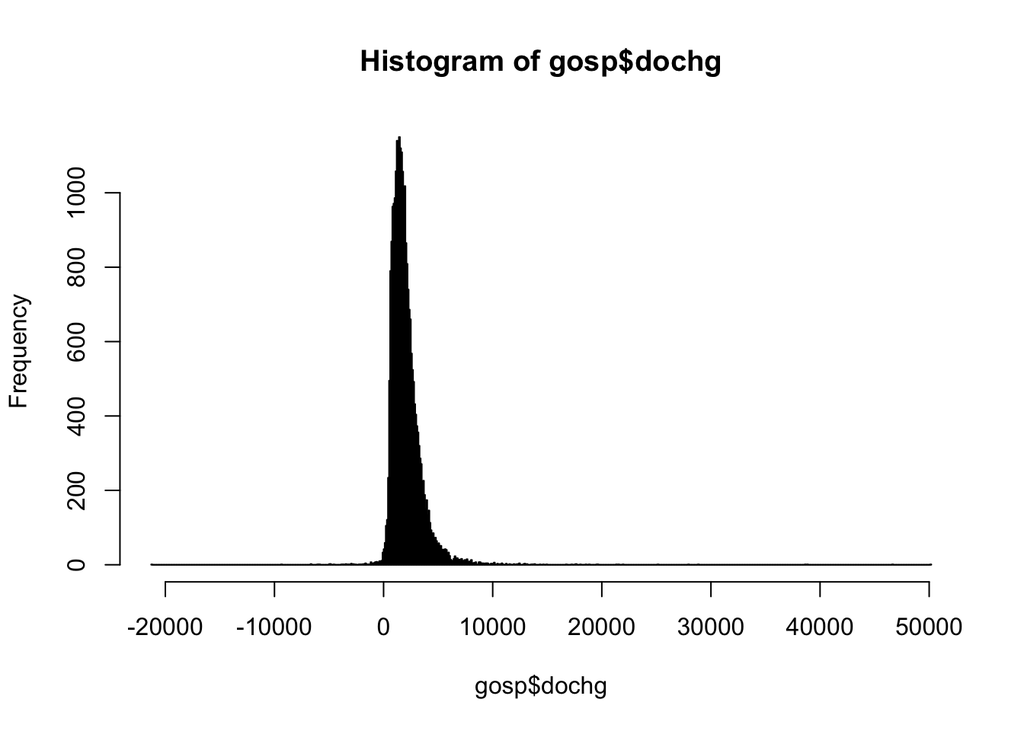

```r
hist(gosp$dochg, breaks = "fd")
```

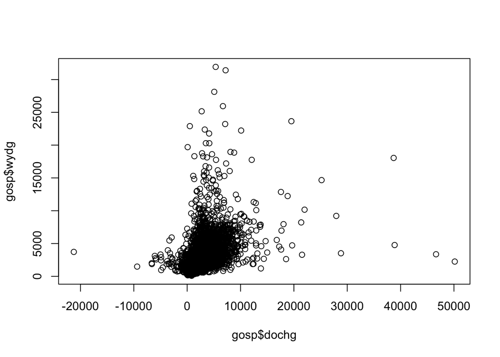

```r
plot(gosp$dochg, gosp$wydg)
```

```r
table(gosp$los)
```

```
   1 1.06 1.26  1.5 1.52 1.57 1.61 1.67  1.7  1.9 1.97    2  2.1 2.32 2.33 2.43
3758    1    1    1    2    2    1    1    1    2    2 6324    1    1    2    1
2.48 2.61 2.65 2.71 2.73 2.81 2.84 2.87 2.97    3 3.07  3.1 3.13 3.19 3.23 3.35
   1    1    1    1    2    1    2    2    1 5615    1    2    1    3    1    1
3.43  3.5 3.52 3.53 3.61 3.67 3.68 3.71 3.74 3.79 3.94    4  4.1 4.35 4.39 4.42
   1    2    1    1    1    1    3    1    1    1    1 5505    1    1    1    2
4.55 4.57 4.77  4.9    5 5.06  5.1 5.13 5.21 5.37 5.42 5.47 5.48 5.58 5.73 5.83
   2    1    3    1 2684    1    1    2    1    1    1    1    1    1    1    1
5.93 5.97    6 6.03  6.3 6.39 6.45  6.5 6.61    7 7.57    8 8.61    9 9.94   10
   2    2 1199    1    1    1    1    1    1  520    1  202    1   72    1   32
  11   12   13   14
  15    5    1    2
```

```r
table(gosp$dochg<0)
```

```
FALSE  TRUE
25894   131
```

```r
summary(gosp$los)
```

```
   Min. 1st Qu.  Median    Mean 3rd Qu.    Max.    NA's
  1.000   2.000   3.000   3.179   4.000  14.000    6462
```

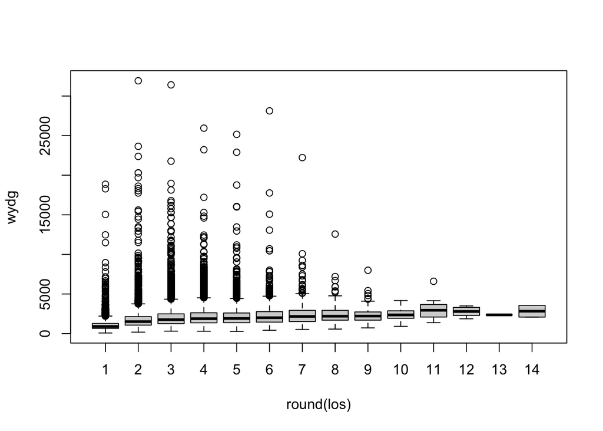

```r
boxplot(wydg ~ round(los), gosp)
```

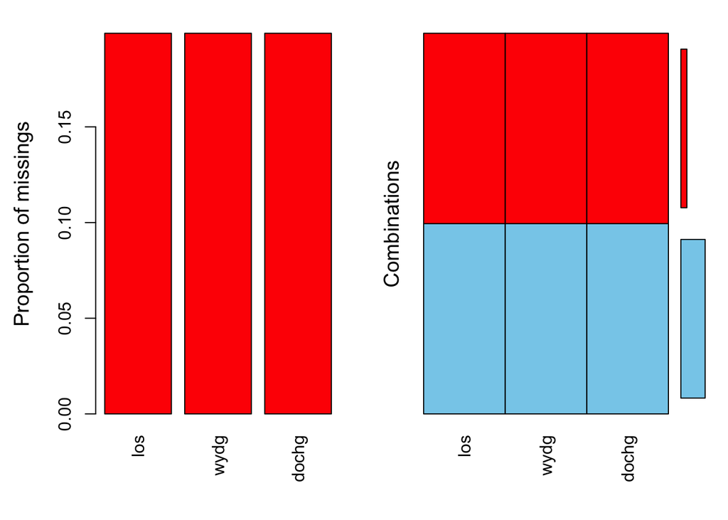

```
 Missings per variable:
 Variable Count
      los  6462
     wydg  6462
    dochg  6462

 Missings in combinations of variables:
 Combinations Count  Percent
        0:0:0 26025 80.10897
        1:1:1  6462 19.89103
```

```r
summary(aggr(gosp[, c("los", "wydg", "dochg")]))
```

```r
gosp[, names(gosp)[1:13] := lapply(.SD, as.factor), .SDcols = names(gosp)[1:13]]
gosp[, los:= floor(los)]
table(gosp$d38, gosp$los)
```

```
        1    2    3    4    5    6    7    8    9   10   11   12   13   14
  0    18    8    5    1    2    0    0    0    0    0    0    0    0    0
  1  1349 1008  620  430  181   75   31   14    5    0    2    0    0    0
  2  1598 2692 2152 1806  718  260   98   41   15   10    2    0    0    0
  3   603 1833 1842 1993  988  413  162   60   28   10    6    2    1    1
  4   141  495  589  693  435  226  104   38   12    6    1    2    0    1
  5    43  199  269  386  229  140   60   23    4    6    1    1    0    0
  6    14   69  116  145  105   68   36   21    4    0    1    0    0    0
  7     5   27   30   42   34   17   22    4    4    0    2    0    0    0
  8     0    8   10   12    5    5    4    2    1    0    0    0    0    0
  9     1    2    2    5    1    1    3    0    0    0    0    0    0    0
  10    0    0    3    0    2    0    1    0    0    0    0    0    0    0
  11    0    0    0    1    0    0    0    0    0    0    0    0    0    0
  12    0    0    0    2    0    0    0    0    0    0    0    0    0    0
  17    0    0    0    1    0    0    0    0    0    0    0    0    0    0
```

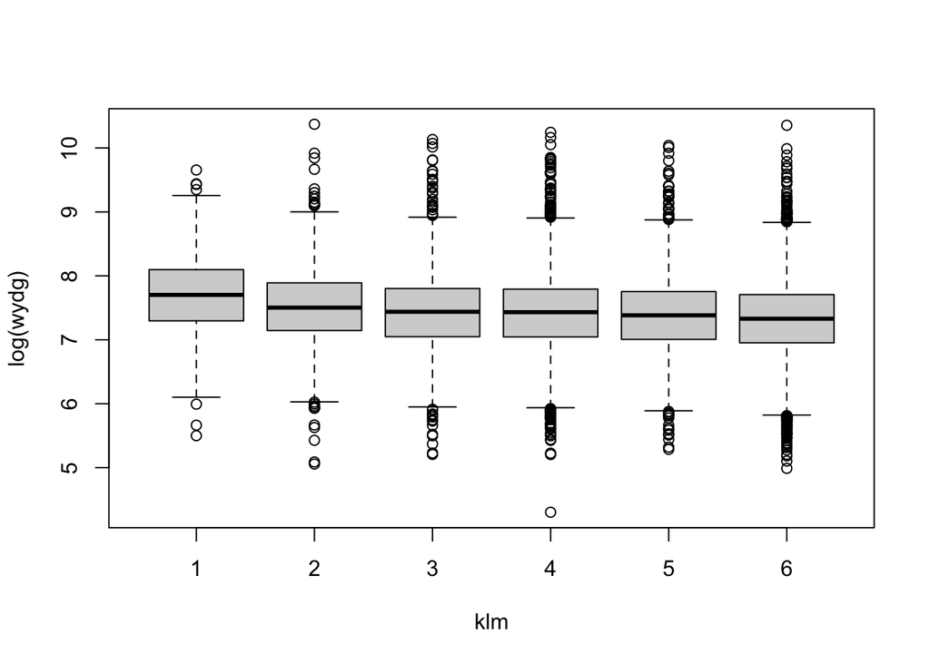

```r
boxplot(log(wydg) ~ klm, data=gosp)
```

```r
summary(lm(log(los) ~ trb + zut, data=gosp))
```

```
Call:
lm(formula = log(los) ~ trb + zut, data = gosp)

Residuals:
     Min       1Q   Median       3Q      Max
-1.15408 -0.03207  0.00366  0.01487  1.34544

Coefficients:
             Estimate Std. Error  t value Pr(>|t|)
(Intercept)  0.687692   0.003757  183.062  < 2e-16 ***
trb2         0.401445   0.004827   83.158  < 2e-16 ***
trb3         0.684772   0.004766  143.683  < 2e-16 ***
trb4         0.902850   0.006476  139.404  < 2e-16 ***
trb5         1.156301   0.008930  129.481  < 2e-16 ***
trb6         0.246577   0.007716   31.955  < 2e-16 ***
trb7         0.177172   0.022626    7.831 5.04e-15 ***
trb8         0.920980   0.005122  179.821  < 2e-16 ***
trb9         0.665949   0.011176   59.588  < 2e-16 ***
trb10        0.254374   0.017075   14.898  < 2e-16 ***
trb11       -0.687955   0.004348 -158.226  < 2e-16 ***
trb12        0.466385   0.004012  116.238  < 2e-16 ***
zut2         0.090344   0.004668   19.352  < 2e-16 ***
zut3         0.032330   0.005933    5.449 5.11e-08 ***
zut4         0.015227   0.005326    2.859 0.004255 **
zut5         0.001793   0.003681    0.487 0.626227
zut6        -0.014609   0.004127   -3.540 0.000401 ***
zut7         0.029329   0.005324    5.509 3.65e-08 ***
---
Signif. codes:  0 '***' 0.001 '**' 0.01 '*' 0.05 '.' 0.1 ' ' 1

Residual standard error: 0.1939 on 26007 degrees of freedom
  (6462 observations deleted due to missingness)
Multiple R-squared:  0.8764,    Adjusted R-squared:  0.8763
F-statistic: 1.085e+04 on 17 and 26007 DF,  p-value: < 2.2e-16
```

```r
summary(lm(log(dochg+22000) ~ trb + zut, data=gosp))
```

```
Call:
lm(formula = log(dochg + 22000) ~ trb + zut, data = gosp)

Residuals:
    Min      1Q  Median      3Q     Max
-3.4632 -0.0267 -0.0068  0.0172  1.1034

Coefficients:
             Estimate Std. Error  t value Pr(>|t|)
(Intercept) 10.100141   0.001061 9517.161  < 2e-16 ***
trb2         0.000716   0.001364    0.525 0.599603
trb3        -0.001291   0.001346   -0.959 0.337579
trb4        -0.006984   0.001830   -3.817 0.000135 ***
trb5        -0.006314   0.002523   -2.503 0.012326 *
trb6        -0.021685   0.002180   -9.948  < 2e-16 ***
trb7        -0.025180   0.006392   -3.939 8.19e-05 ***
trb8         0.021643   0.001447   14.959  < 2e-16 ***
trb9        -0.003252   0.003157   -1.030 0.303055
trb10       -0.005355   0.004824   -1.110 0.266957
trb11       -0.033443   0.001228  -27.227  < 2e-16 ***
trb12        0.007957   0.001133    7.020 2.28e-12 ***
zut2        -0.008711   0.001319   -6.605 4.04e-11 ***
zut3        -0.024996   0.001676  -14.913  < 2e-16 ***
zut4         0.020414   0.001505   13.567  < 2e-16 ***
zut5        -0.018535   0.001040  -17.822  < 2e-16 ***
zut6        -0.034274   0.001166  -29.395  < 2e-16 ***
zut7        -0.042024   0.001504  -27.941  < 2e-16 ***
---
Signif. codes:  0 '***' 0.001 '**' 0.01 '*' 0.05 '.' 0.1 ' ' 1

Residual standard error: 0.05477 on 26007 degrees of freedom
  (6462 observations deleted due to missingness)
Multiple R-squared:  0.1654,    Adjusted R-squared:  0.1648
F-statistic: 303.1 on 17 and 26007 DF,  p-value: < 2.2e-16
```

```r
car::Anova(lm(log(wydg) ~ d61 + klm + woj + trb + zut, data=gosp))
```

```
Anova Table (Type II tests)

Response: log(wydg)
          Sum Sq    Df  F value    Pr(>F)
d61        987.2     4 1158.811 < 2.2e-16 ***
klm        164.3     5  154.280 < 2.2e-16 ***
woj         36.3    15   11.353 < 2.2e-16 ***
trb       1021.5    11  436.025 < 2.2e-16 ***
zut        188.2     6  147.281 < 2.2e-16 ***
Residuals 5534.1 25983
---
Signif. codes:  0 '***' 0.001 '**' 0.01 '*' 0.05 '.' 0.1 ' ' 1
```

Kod na imputację danych

```r
set.seed(2025)
gosp$flag <- is.na(gosp$los)
gosp_naraz_pmm <- gosp |>
  impute_pmm(los + wydg + dochg ~ zut + trb + d61 + d63 + klm)

gosp_naraz_knn <- gosp |>
  impute_knn(los + wydg + dochg ~ zut + trb + d61 + d63 + klm)

gosp_naraz_regd <- gosp |>
  impute_lm(los + wydg + dochg ~ zut + trb + d61 + d63 + klm)

gosp_naraz_regs <- gosp |>
  impute_lm(los + wydg + dochg ~ zut + trb + d61 + d63 + klm, add_residual = "observed")


gosp_pokolei_pmm <- gosp |>
  impute_pmm(los ~ zut + trb + d61 + d63 + klm) |>
  impute_pmm(dochg ~ los + zut + trb + d61 + d63 + klm) |>
  impute_pmm(wydg ~ dochg + los + zut + trb + d61 + d63 + klm)

gosp_pokolei_knn <- gosp |>
  impute_knn(los ~ zut + trb + d61 + d63 + klm) |>
  impute_knn(dochg ~ los + zut + trb + d61 + d63 + klm) |>
  impute_knn(wydg ~ dochg + los + zut + trb + d61 + d63 + klm)

gosp_pokolei_regd <- gosp |>
  impute_lm(los ~ zut + trb + d61 + d63 + klm) |>
  impute_lm(dochg ~ los + zut + trb + d61 + d63 + klm) |>
  impute_lm(wydg ~ dochg + los + zut + trb + d61 + d63 + klm)

gosp_pokolei_regs <- gosp |>
  impute_lm(los ~ zut + trb + d61 + d63 + klm, add_residual = "observed") |>
  impute_lm(dochg ~ los + zut + trb + d61 + d63 + klm, add_residual = "observed") |>
  impute_lm(wydg ~ dochg + los + zut + trb + d61 + d63 + klm, add_residual = "observed")
```

Kod na podsumowanie danych

```r
tab_wyniki <- rbind(
  colMeans(gosp_naraz_pmm[, c("los", "dochg", "wydg")]),
  colMeans(gosp_naraz_knn[, c("los", "dochg", "wydg")]),
  colMeans(gosp_naraz_regd[, c("los", "dochg", "wydg")]),
  colMeans(gosp_naraz_regs[, c("los", "dochg", "wydg")]),
  colMeans(gosp_pokolei_pmm[, c("los", "dochg", "wydg")]),
  colMeans(gosp_pokolei_knn[, c("los", "dochg", "wydg")]),
  colMeans(gosp_pokolei_regd[, c("los", "dochg", "wydg")]),
  colMeans(gosp_pokolei_regs[, c("los", "dochg", "wydg")])
)
tab_wyniki <- as.data.frame(tab_wyniki)
tab_wyniki$jak <- rep(c("naraz", "pokolei"), each  = 4)
tab_wyniki$metoda <- rep(c("pmm", "knn", "regd", "regs"), times = 2)
tab_wyniki
```

```
       los    dochg     wydg     jak metoda
1 3.071813 2173.425 2048.067   naraz    pmm
2 3.078616 2081.162 1987.786   naraz    knn
3 3.062712 2137.513 2028.987   naraz   regd
4 3.066386 2139.500 2031.979   naraz   regs
5 3.068243 2158.895 2049.142 pokolei    pmm
6 3.081817 2086.771 1986.446 pokolei    knn
7 3.062712 2137.513 2028.987 pokolei   regd
8 3.064823 2137.115 2030.439 pokolei   regs
```

```r
mean(gosp$los,na.rm=T)
```

```
[1] 3.176945
```

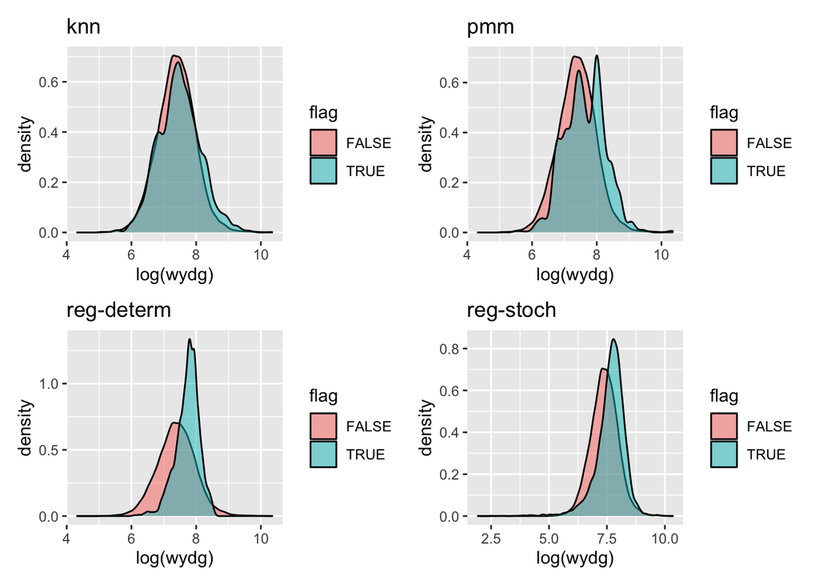

```r
p1 <- ggplot(data=gosp_naraz_knn, aes(x = log(wydg), fill = flag)) +
  geom_density(alpha = 0.5) + labs(title = "knn")
p2 <- ggplot(data=gosp_naraz_pmm, aes(x = log(wydg), fill = flag)) +
  geom_density(alpha = 0.5) + labs(title = "pmm")
p3 <- ggplot(data=gosp_naraz_regd, aes(x = log(wydg), fill = flag)) +
  geom_density(alpha = 0.5) + labs(title = "reg-determ")
p4 <- ggplot(data=gosp_naraz_regs, aes(x = log(wydg), fill = flag)) +
  geom_density(alpha = 0.5) + labs(title = "reg-stoch")

(p1 + p2) / (p3 + p4)
```

**Python**

Kod na wczytanie pakietu do wczytania danych

```python
import pandas as pd
import numpy as np
import matplotlib.pyplot as plt
import seaborn as sns
from sklearn.impute import KNNImputer
from sklearn.linear_model import LinearRegression
from scipy import stats
import statsmodels.api as sm
import statsmodels.formula.api as smf
from statsmodels.stats.anova import anova_lm
```